# parameter_combo_testing

Laurie Lyon

2025-03-26

# Comparison of MICOM-predicted growth rates and measured changes in relative abundance from time series data

Load in libraries

```r
library(cowplot) # to plot grid
library(glue) # to format and interpolate a string
library(lme4) # for linear modeling
library(tidyverse)
library(ggh4x) # ggplot2 extension, includes nested facets
library(broom)
```

Load in combined data generated from combine_sim_and_real_data.r (within data folder of micom-time-series project folder)

Choosing file generated from 50% prevalence value cutoff (taxon present in at least half of all sampling timepoints)

```r
sim_real_data <- read_csv("../data/combined_sim_real_data.csv")
```

## Measuring Spearman Correlation

Goal: I want to see the correlation between micom predicted growth rates and actual CLR-transformed changes in abundance

Using Spearman Correlation as a nonparametric alternative to measuring monotonic correlation between samples

Plan of attack:

- can I write a for loop to cycle though all of these combinations - top level: folder_name/parameters, further nested by taxon, possibly further nested by before vs. after onset of illness?
- how can I extract the values that I want from the Spearman test. Do I filter first by significance?
- Can I average the rho values across all the taxa in a single folder?
- How can I quantify what parameters are performing better than others
  - rank by p-value and rho, count instances of each parameter and where they fall in the ranking?

### Spearman results for all genera, all samples, all parameter combinations

- further split by date_vs_onset_illness to see if there are differences between the “undisturbed” and “disturbed” gut parameters in this dataset
- usig group_by and broom to cycle through parameter combinations and taxa

```r
spearman_results <- sim_real_data %>%
  #group by folder_name and taxon then perform spearman correlation tests systematically
  group_by(folder_name, taxon, subject_id, model_db, diet, tradeoff, date_vs_onset_illness) %>%
  #nest rows into a list-column of dfs, each unique group has its own df with all rows belonging to that group (data column)
  nest() %>%
  #first filter groups with non-zero variance (was causing errors in several samples)
  #map() applies a function to each element of a vector (map_dbl return a vector of type dbl)
  mutate(
    var_growth = map_dbl(data, ~ sd(.x$growth_rate, na.rm=TRUE)),
    var_abund = map_dbl(data, ~sd(.x$clr_change_abund, na.rm=TRUE))
  ) %>%
  #removes zero variance cases
  filter(var_growth > 0 & var_abund > 0) %>%
  mutate(
    #map applies a function to each element of a vector
    spearman = map(data, ~ cor.test(.x$growth_rate,
                                    .x$clr_change_abund,
                                    method = "spearman",
                                    #received warning about computing exact p-value with ties
                                    #default to approx. p-values to deal with this
                                    exact = FALSE)),
    #extracts the rho and p-values from spearman with broom::tidy()
    tidy_results = map(spearman, tidy)
  ) %>%
  #extract tidy results into a new df
  unnest(tidy_results) %>%
  select(-data, -spearman, -var_growth, -var_abund)

nrow(spearman_results)
```

```
## [1] 6681
```

```r
# summary(spearman_results)
```

But how many of these are statistically significant?

```r
spearman_significant_p <- spearman_results %>%
  filter(p.value < 0.05)

nrow(spearman_significant_p)
```

```
## [1] 1001
```

```r
significant_p_percentage <- (nrow(spearman_significant_p)/nrow(spearman_results))*100
```

### Performance Summary - Spearman Correlations

I want a type of summary that tells me how many of these correlations are statistically significant (p < 0.05), and of these, how many are positive vs. negatively correlated (positive or negative rho value)

```r
spearman_significant_p_summary <- spearman_results %>%
  #add columns for significance and directionality
  mutate(significant = p.value < 0.05,
         positive = estimate > 0,
         negative = estimate < 0,
         significant_positive = significant & positive,
         significant_negative = significant & negative)
```

```r
spearman_performance_summary_temporal <- spearman_results %>%
  #add columns for significance and directionality
  mutate(significant = p.value < 0.05,
         positive = estimate > 0,
         negative = estimate < 0,
         significant_positive = significant & positive,
         significant_negative = significant & negative) %>%
  group_by(folder_name,
           subject_id,
           model_db,
           diet,
           tradeoff,
           date_vs_onset_illness) %>%
  summarise(
    mean_rho = mean(estimate[significant_positive],
                    na.rm = TRUE),
    median_rho = median(estimate[significant_positive],
                        na.rm = TRUE),
    significant_taxa = sum(significant),
    significant_positive_taxa = sum(significant_positive),
    significant_negative_taxa = sum(significant_negative),
    total_taxa = n(),
    percent_significant = (significant_taxa / total_taxa)*100,
    percent_significant_positive = (significant_positive_taxa /
                                    total_taxa)*100,
    percent_significant_negative = (significant_negative_taxa /
                                    total_taxa)*100,
    pos_to_neg_ratio = significant_positive_taxa / (significant_negative_taxa + 1),
    pos_fraction = significant_positive_taxa /
                 (significant_positive_taxa + significant_negative_taxa),
    pos_minus_neg = significant_positive_taxa - significant_negative_taxa
  ) %>%
  #only want positive rho values
  #filter(significant_positive_taxa > 0) %>%
  arrange(desc(pos_minus_neg), desc(percent_significant_positive), desc(median_rho))
```

[output not shown]

```r
spearman_performance_summary <- spearman_results %>%
  #add columns for significance and directionality
  mutate(significant = p.value < 0.05,
         positive = estimate > 0,
         negative = estimate < 0,
         significant_positive = significant & positive,
         significant_negative = significant & negative) %>%
  group_by(folder_name,
           subject_id,
           model_db,
           diet,
           tradeoff) %>%
  summarise(
    mean_rho = mean(estimate[significant_positive],
                    na.rm = TRUE),
    median_rho = median(estimate[significant_positive],
                        na.rm = TRUE),
    significant_taxa = sum(significant),
    significant_positive_taxa = sum(significant_positive),
    significant_negative_taxa = sum(significant_negative),
    total_taxa = n(),
    percent_significant = (significant_taxa / total_taxa)*100,
    percent_significant_positive = (significant_positive_taxa /
                                    total_taxa)*100,
    percent_significant_negative = (significant_negative_taxa /
                                    total_taxa)*100,
    pos_minus_neg = significant_positive_taxa - significant_negative_taxa
  ) %>%
  #only want positive rho values
  #filter(significant_positive_taxa > 0) %>%
  arrange(desc(pos_minus_neg), desc(percent_significant_positive), desc(median_rho))
```

[output not shown]

### Graphing outcomes

```r
# #define the categories I want to cycle through
# #unique() returns a vector, df, or array like x but with duplicate elements removed
# subjects <- unique(spearman_performance_summary$subject_id)
# onset_timing <- unique(spearman_performance_summary$date_vs_onset_illness)
#
# #create and store the plots in a nested list like my data from earlier
# #expand.grid() creates a df from all combinations of supplied vectors
# spearman_predictive_accuracy_plots <- expand.grid(subject = subjects, onset = onset_timing) %>%
# #pmap maps in parallel
#   pmap(function(subject, onset) {
#     spearman_performance_summary %>%
#       filter(subject_id == subject,
#              date_vs_onset_illness == onset,
#              pos_minus_neg > 0) %>%
#       ggplot(aes(x = reorder(folder_name, significant_positive_taxa),
#                  y = pos_minus_neg,
#                  fill = median_rho)) +
#       #makes bar plot with actual data values (percent_significant_positive)
#       #default is stat = "counts"
#       geom_bar(stat = "identity", color = "black") +
#       #put folder names on the side for easier readability
#       coord_flip() +
#       scale_fill_gradient(low = "lightyellow",
#                           high = "darkgreen") +
#       labs(x = "Parameter Combination (folder_name)",
#         y = "# Significant Positive Taxa - Significant Negative Taxa",
#         fill = "Median Rho",
#         title = paste("MICOM Parameter Rankings for ", subject),
#         subtitle = paste("Time relative to illness onset: ", onset,
#                          "\nRanked by # Significant Positive Taxa; color = Median Rho")
#       ) +
#       theme_minimal() +
#       theme(legend.position = "right")
#
#   })
#
# #name the plots
# names(spearman_predictive_accuracy_plots) <- expand.grid(
#   subject = subjects, onset = onset_timing) %>%
#   mutate(plot_name = paste(subject, onset, sep = "_")) %>%
#   pull(plot_name)
```

```r
# Define the unique subjects to iterate over
subjects <- unique(spearman_performance_summary$subject_id)
#also want to split by before/after onset of illness?

# Create and store the plots in a list using purrr::map
spearman_predictive_accuracy_plots <- purrr::map(subjects, function(subject) {
  spearman_performance_summary %>%
    filter(subject_id == subject,
           pos_minus_neg > 0) %>%
    ggplot(aes(x = reorder(folder_name, pos_minus_neg),
               y = pos_minus_neg,
               fill = median_rho)) +
    geom_bar(stat = "identity", color = "black") +
    coord_flip() +
    scale_fill_gradient(low = "lightyellow",
                        high = "darkgreen") +
    labs(x = "Parameter Combination (folder_name)",
         y = "# Significant Positive - # Significant Negative Taxa",
         fill = "Median Rho",
         title = paste("MICOM Parameter Rankings for", subject),
         subtitle = "Ranked by # Significant Positive - # Significant Negative Taxa
         \n color = Median Rho"
    ) +
    theme_minimal() +
    theme(legend.position = "right")
})

# Name the plots with the subject id
names(spearman_predictive_accuracy_plots) <- subjects
```

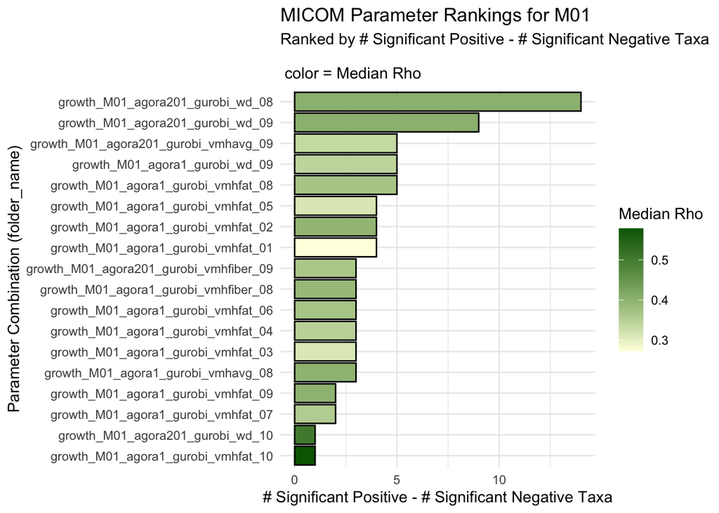

```r
spearman_predictive_accuracy_plots$M01
```

## Saving Plots

- put date/time into filepath
- create new folder for outputs

```r
M01_best_performing_condition <- spearman_results %>%
  filter(folder_name == "growth_M01_agora201_gurobi_wd_08")
```

```r
F01_best_performing_condition <- spearman_results %>%
  filter(folder_name == "growth_F01_agora1_gurobi_wd_09")
```

```r
M02_best_performing_condition <- spearman_results %>%
  filter(folder_name == "growth_M02_agora1_gurobi_vmhfat_07")
```

## EXTRA STUFF FOR PRESENTATION

```r
M01_wd_08_growth <- read_csv("../data/growth_rates/growth_M01_agora201_gurobi_wd_08/growth_rates.csv")
summary(M01_wd_08_growth)
```

```
##    abundance          growth_rate        reactions     metabolites
##  Min.   :0.0001274   Min.   :0.00000   Min.   : 799   Min.   : 755
##  1st Qu.:0.0007987   1st Qu.:0.01240   1st Qu.:1250   1st Qu.:1128
##  Median :0.0049135   Median :0.03641   Median :1585   Median :1271
##  Mean   :0.0334784   Mean   :0.23718   Mean   :1933   Mean   :1614
##  3rd Qu.:0.0281036   3rd Qu.:0.08494   3rd Qu.:2412   3rd Qu.:1860
##  Max.   :0.5738090   Max.   :7.21098   Max.   :4477   Max.   :3577
##     taxon              tradeoff     sample_id
##  Length:2987        Min.   :0.8   Min.   :1.201e+09
##  Class :character   1st Qu.:0.8   1st Qu.:1.203e+09
##  Mode  :character   Median :0.8   Median :1.205e+09
##                     Mean   :0.8   Mean   :1.205e+09
##                     3rd Qu.:0.8   3rd Qu.:1.207e+09
##                     Max.   :0.8   Max.   :1.209e+09
```